# Lab 9

### Exercise 8

Is bty_avg still a significant predictor of score? Has the addition of gender to the model changed the parameter estimate for gender?

Yes, there was a marginal increase in the intercept and slope but not enough to have a significant change on bty_avg as a significant predictor of score.

### Exercise 9

What is the equation of the line corresponding to males? (Hint: For males, the parameter estimate is multiplied by 1.) For two professors who received the same beauty rating, which gender tends to have the higher course evaluation score?

The equation of the line corresponding to males is

$$score = 3.74734 + 0.07416(b) + 0.17239(m)$$
where b is the b is the average beauty rating and m is the classifier “1” given to males. For females we would use the variable f which is classified as a 0.

Males tend to have a higher course evaluation score.

### Exercise 10

Create a new model called m_bty_rank with gender removed and rank added in. How does R appear to handle categorical variables that have more than two levels? Note that the rank variable has three levels: teaching, tenure track, tenured.

```r
m_bty_rank <- lm(score ~ bty_avg + rank, data = evals)
summary(m_bty_rank)
```

```
##
## Call:
## lm(formula = score ~ bty_avg + rank, data = evals)
##
## Residuals:
##     Min      1Q  Median      3Q     Max
## -1.8713 -0.3642  0.1489  0.4103  0.9525
##
## Coefficients:
##                  Estimate Std. Error t value Pr(>|t|)
## (Intercept)       3.98155    0.09078  43.860  < 2e-16 ***
## bty_avg           0.06783    0.01655   4.098 4.92e-05 ***
## ranktenure track -0.16070    0.07395  -2.173   0.0303 *
## ranktenured      -0.12623    0.06266  -2.014   0.0445 *
## ---
## Signif. codes:  0 '***' 0.001 '**' 0.01 '*' 0.05 '.' 0.1 ' ' 1
##
## Residual standard error: 0.5328 on 459 degrees of freedom
## Multiple R-squared:  0.04652,    Adjusted R-squared:  0.04029
## F-statistic: 7.465 on 3 and 459 DF,  p-value: 6.88e-05
```

Since only two categorical variables appear in the results of the linear regression, I would assume that R is purposefully excluding one of the three categories. In this case, the missing category is teaching.

### Exercise 11

Which variable would you expect to have the highest p-value in this model? Why? Hint: Think about which variable would you expect to not have any association with the professor score.

The variable that should be the least likely to have any association with the professor score is the cls_level. In this case, the level of the class as upper or lower should not have any association with the professor score. Additionally, there is often overlap in upper and lower level courses for all students.

### Exercise 12

Check your suspicions from the previous exercise. Include the model output in your response.

```r
m_full <- lm(score ~ rank + gender + ethnicity + language + age + cls_perc_eval
             + cls_students + cls_level + cls_profs + cls_credits + bty_avg
             + pic_outfit + pic_color, data = evals)
summary(m_full)
```

```
##
## Call:
## lm(formula = score ~ rank + gender + ethnicity + language + age +
##     cls_perc_eval + cls_students + cls_level + cls_profs + cls_credits +
##     bty_avg + pic_outfit + pic_color, data = evals)
##
## Residuals:
##      Min       1Q   Median       3Q      Max
## -1.77397 -0.32432  0.09067  0.35183  0.95036
##
## Coefficients:
##                         Estimate Std. Error t value Pr(>|t|)
## (Intercept)            4.0952141  0.2905277  14.096  < 2e-16 ***
## ranktenure track      -0.1475932  0.0820671  -1.798  0.07278 .
## ranktenured           -0.0973378  0.0663296  -1.467  0.14295
## gendermale             0.2109481  0.0518230   4.071 5.54e-05 ***
## ethnicitynot minority  0.1234929  0.0786273   1.571  0.11698
## languagenon-english   -0.2298112  0.1113754  -2.063  0.03965 *
## age                   -0.0090072  0.0031359  -2.872  0.00427 **
## cls_perc_eval          0.0053272  0.0015393   3.461  0.00059 ***
## cls_students           0.0004546  0.0003774   1.205  0.22896
## cls_levelupper         0.0605140  0.0575617   1.051  0.29369
## cls_profssingle       -0.0146619  0.0519885  -0.282  0.77806
## cls_creditsone credit  0.5020432  0.1159388   4.330 1.84e-05 ***
## bty_avg                0.0400333  0.0175064   2.287  0.02267 *
## pic_outfitnot formal  -0.1126817  0.0738800  -1.525  0.12792
## pic_colorcolor        -0.2172630  0.0715021  -3.039  0.00252 **
## ---
## Signif. codes:  0 '***' 0.001 '**' 0.01 '*' 0.05 '.' 0.1 ' ' 1
##
## Residual standard error: 0.498 on 448 degrees of freedom
## Multiple R-squared:  0.1871, Adjusted R-squared:  0.1617
## F-statistic: 7.366 on 14 and 448 DF,  p-value: 6.552e-14
```

My assumption was incorrect. Cls_profs had the highest p-value and thus the least likely association with score. This categorical variable observes whether the course had multiple professors teaching sections in the course or if there was only a single professor teaching all sections for the course. It turns out that this has little to no influence on the professor score.

### Exercise 13

Interpret the coefficient associated with the ethnicity variable.

Holding all other variables constant, we would expect that a non-minority professor would rate about 0.1235 points higher on their evaluations. However, given the large p-value the results would not be significant as there is a poor association between the professor’s ethnicity and the professor’s score.

### Exercise 14

Drop the variable with the highest p-value and re-fit the model. Did the coefficients and significance of the other explanatory variables change? (One of the things that makes multiple regression interesting is that coefficient estimates depend on the other variables that are included in the model.) If not, what does this say about whether or not the dropped variable was collinear with the other explanatory variables?

```r
m_full_drop1 <- lm(score ~ rank + gender + ethnicity + language + age + cls_perc_eval
             + cls_students + cls_level + cls_credits + bty_avg
             + pic_outfit + pic_color, data = evals)
summary(m_full_drop1)
```

```
##
## Call:
## lm(formula = score ~ rank + gender + ethnicity + language + age +
##     cls_perc_eval + cls_students + cls_level + cls_credits +
##     bty_avg + pic_outfit + pic_color, data = evals)
##
## Residuals:
##     Min      1Q  Median      3Q     Max
## -1.7836 -0.3257  0.0859  0.3513  0.9551
##
## Coefficients:
##                         Estimate Std. Error t value Pr(>|t|)
## (Intercept)            4.0872523  0.2888562  14.150  < 2e-16 ***
## ranktenure track      -0.1476746  0.0819824  -1.801 0.072327 .
## ranktenured           -0.0973829  0.0662614  -1.470 0.142349
## gendermale             0.2101231  0.0516873   4.065 5.66e-05 ***
## ethnicitynot minority  0.1274458  0.0772887   1.649 0.099856 .
## languagenon-english   -0.2282894  0.1111305  -2.054 0.040530 *
## age                   -0.0089992  0.0031326  -2.873 0.004262 **
## cls_perc_eval          0.0052888  0.0015317   3.453 0.000607 ***
## cls_students           0.0004687  0.0003737   1.254 0.210384
## cls_levelupper         0.0606374  0.0575010   1.055 0.292200
## cls_creditsone credit  0.5061196  0.1149163   4.404 1.33e-05 ***
## bty_avg                0.0398629  0.0174780   2.281 0.023032 *
## pic_outfitnot formal  -0.1083227  0.0721711  -1.501 0.134080
## pic_colorcolor        -0.2190527  0.0711469  -3.079 0.002205 **
## ---
## Signif. codes:  0 '***' 0.001 '**' 0.01 '*' 0.05 '.' 0.1 ' ' 1
##
## Residual standard error: 0.4974 on 449 degrees of freedom
## Multiple R-squared:  0.187,  Adjusted R-squared:  0.1634
## F-statistic: 7.943 on 13 and 449 DF,  p-value: 2.336e-14
```

Yes, there were slight changes in the the coefficients and significance of the other explanatory variables.

### Exercise 15

Using backward-selection and p-value as the selection criterion, determine the best model. You do not need to show all steps in your answer, just the output for the final model. Also, write out the linear model for predicting score based on the final model you settle on.

```r
m_full_best <- lm(score ~ gender
                  + ethnicity
                  + age
                  + language
                  + cls_perc_eval
              + cls_credits
              + bty_avg
             + pic_color, data = evals)
summary(m_full_best)
```

```
##
## Call:
## lm(formula = score ~ gender + ethnicity + age + language + cls_perc_eval +
##     cls_credits + bty_avg + pic_color, data = evals)
##
## Residuals:
##      Min       1Q   Median       3Q      Max
## -1.85320 -0.32394  0.09984  0.37930  0.93610
##
## Coefficients:
##                        Estimate Std. Error t value Pr(>|t|)
## (Intercept)            3.771922   0.232053  16.255  < 2e-16 ***
## gendermale             0.207112   0.050135   4.131 4.30e-05 ***
## ethnicitynot minority  0.167872   0.075275   2.230  0.02623 *
## age                   -0.006046   0.002612  -2.315  0.02108 *
## languagenon-english   -0.206178   0.103639  -1.989  0.04726 *
## cls_perc_eval          0.004656   0.001435   3.244  0.00127 **
## cls_creditsone credit  0.505306   0.104119   4.853 1.67e-06 ***
## bty_avg                0.051069   0.016934   3.016  0.00271 **
## pic_colorcolor        -0.190579   0.067351  -2.830  0.00487 **
## ---
## Signif. codes:  0 '***' 0.001 '**' 0.01 '*' 0.05 '.' 0.1 ' ' 1
##
## Residual standard error: 0.4992 on 454 degrees of freedom
## Multiple R-squared:  0.1722, Adjusted R-squared:  0.1576
## F-statistic:  11.8 on 8 and 454 DF,  p-value: 2.58e-15
```

The best linear model for predicting score based on backward-selection and p-value significance is:

$$score = 3.771922+0.207112(gender)+0.167872(ethnicity)-0.006046(age) - 0.206178(language) +0.004656(cls_perc_eval)+ 0.505306(cls_credits)+ 0.051069(bty_avg)-0.190579 (pic_color)$$

### Exercise 16

Verify that the conditions for this model are reasonable using diagnostic plots.

The conditions are:

```
* Linearity
* ~ Normal Residuals
* Constant Variability
* Independent Observations
```

We can evaluate using the diagnostic plots of the final regression.

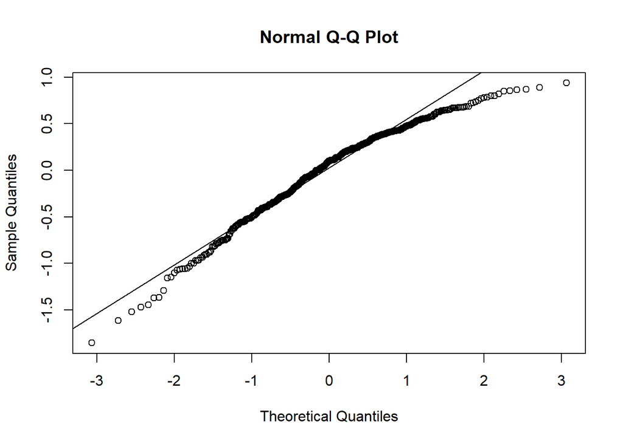

```r
m_bty_final <- lm(score ~ ethnicity
                  + gender
                  + language
                  + age
                  + cls_perc_eval
              + cls_credits
              + bty_avg
              + pic_color, data = evals)
qqnorm(m_bty_final$residuals)
qqline(m_bty_final$residuals)
```

There is a slight deviation from normal towards both ends of this plot, but it is still nearly normal. It is also reasonbly linear.

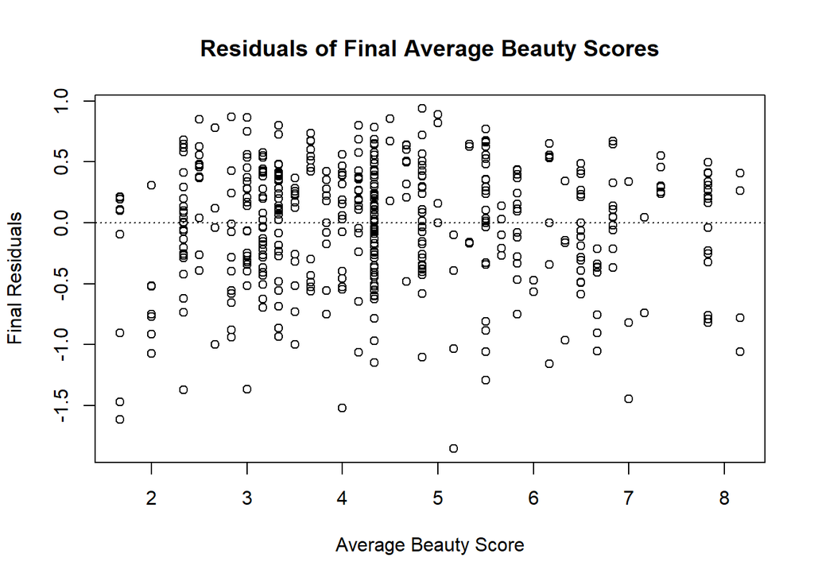

```r
plot(m_bty_final$residuals ~ evals$bty_avg, xlab = "Average Beauty Score", ylab = "Final Residuals", main = "Residuals of Final Average Beauty Scores")
abline(h = 0, lty = 3)
```

The residuals appear relativly constant in their variability. They are also nearly normal and reasonbly spread around the zero line.

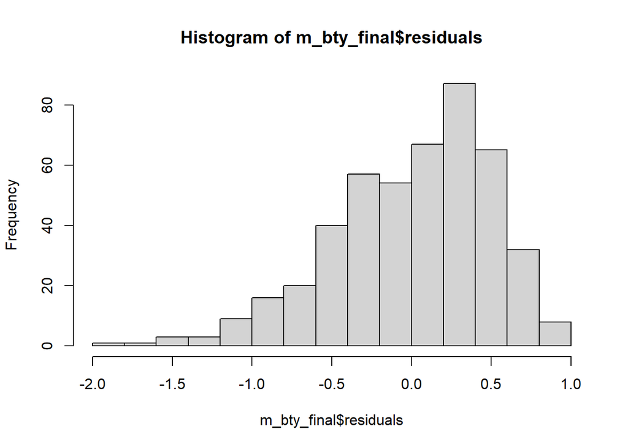

```r
hist(m_bty_final$residuals)
```

In this histogram we can see a slight left skew, however, it might not be enough to worry about. Assuming that each observation is independent since each student made their own decisions about a single professor just once and separately without influence of another’s evaluation, then these conditions have been met.

### Exercise 17

The original paper describes how these data were gathered by taking a sample of professors from the University of Texas at Austin and including all courses that they have taught. Considering that each row represents a course, could this new information have an impact on any of the conditions of linear regression?

Yes, this new information would violate the condition independent observations.

### Exercise 18

Based on your final model, describe the characteristics of a professor and course at University of Texas at Austin that would be associated with a high evaluation score.

Based on the final model, the characteristics of a professor and course at the University of Texas at Austin that would be associated with a high evaluation score are:

[output not shown]

### Exercise 19

Would you be comfortable generalizing your conclusions to apply to professors generally (at any university)? Why or why not?

No, I would not be comfortable generalizing these conclusions to apply to professors generally at any university. To start, although this model was selected for statistical significance, it was entirely based on the population of students at one unversity in one place for a specific set of time. This will change over-time. Our ability to predict the values is also very low, as evident in the low R-squared and Adjusted R-sqaured values. There are also many cultural norms and perceived benefits of professors in Austin that will not be seen as a benefit to students in another country.

For example, if this were applied at the University of Osmani in Hyderabad, India, the model would likely render itself ineffective even with huge samples of the population. This is a minority dominated, non-english based, male-dominated school. Professors are often much older and the cultural norms of what makes a person beautiful at this University take a very different perspective than what students at the University of Austin would say. The variables in the model would no longer hold normal and conditions for regression would no longer be met.

…